# First

```python
import numpy as np
import matplotlib.pyplot as plt
import pandas as pd
import seaborn as sns
import collections
```

## Importing Packages

- numpy NumPy is the fundamental package for scientific computing in Python. It is a Python library that provides a  
  multidimensional array object, various derived objects (such as masked arrays and matrices), and an assortment of routines for fast operations on arrays, including mathematical, logical, shape manipulation
- matplotlib matplotlib is a another primarily used package in Data Sciences to plot the trends in form of different graphical representations, for example, histogram, pie chart, bar graph, etc.
- pandas pandas is a Python package providing fast, flexible, and expressive data structures designed to make working with “relational” or “labeled” data both easy and intuitive. It aims to be the fundamental high-level building block for doing practical, real world data analysis in Python. Additionally, it has the broader goal of becoming the most powerful and flexible open source data analysis / manipulation tool available in any language. It is already well on its way toward this goal. We deal with all dataframes and series in pandas.
- seaborn It is another package which works as a complimentary package with matplotlib. It beautifies and details the graphs.
- collections It is used to sort dictionaries.

How to download these packages, **[click here](https://stackoverflow.com/questions/42907331/how-to-install-pandas-from-pip-on-windows-cmd)**

```python
df=pd.read_csv('train.csv')

x=df[['PassengerId','Survived','Pclass','Sex','Age']]
total_rows=len(x.axes[0])
print("The analysis is carried out on " + str(total_rows+1) + " passengers travelling in titanic")
```

```
The analysis is carried out on 892 passengers travelling in titanic
```

## Reading the excel or csv file:

In the above lines of code, initially **pd.read_csv('Name_of_the_file.csv')** is used in order to read the csv file from the path mentioned and store it in form of a dataframe in a variable named **df**

## Picking up of necessary data:

x is another variable that stores the dataframe which are needed to carry out simple data analysis that we have conducted. there are many other columns in the csv file, like name, etc. which we do not need currently for our data analysis. Hence, we have filtered the data with only the columns we need.

<font color = blue> Further, we have printed the number of passengers on board, so we can display the *Sample Size* of the Data Analysis.

```python
Children=x['Age']<18
Adults= (x['Age']>18) & (x['Age']<=30)
Elders=(x['Age']>30) & (x['Age']<60)
SeniorCitizens= x['Age']>60

class1= x['Pclass']==1
class2= x['Pclass'] == 2
class3= x['Pclass'] == 3
survived=x['Survived']==1
```

## Divising of the Columns on the basis of constraints:

We have classified the data present in the **Age** Column into 4 main categories to find the age groups i,e, Children, Adults, Elders, Senior Citizens.

Further, the passengers are filtered according to their classess i.e. Class 1, Class 2, Class 3.

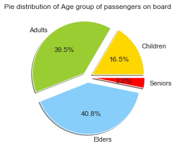

```python
labels = 'Children','Adults','Elders','Seniors'
sizes = [len(x[Children].axes[0]),len(x[Adults].axes[0]),len(x[Elders].axes[0]),len(x[SeniorCitizens].axes[0])]

plt.pie(sizes,labels=labels,shadow=True,colors = ['gold', 'yellowgreen', 'lightskyblue','red'],explode=(0.1,0.1,0.1,0.1),autopct='%1.1f%%')
plt.title('Pie distribution of Age group of passengers on board')
plt.show()
```

## Pie Chart of Age groups on board

In the above pie chart, we can observe the distribution of total number of passengers on board. This is a representation of how the Main Sample is divided on the basis of age group.

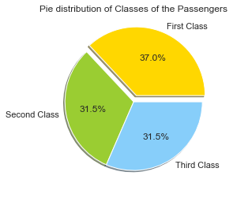

```python
size_class= [len(x[class1].axes[0]),len(x[class2].axes[0]),len(x[class2].axes[0])]
plt.title('Pie distribution of Classes of the Passengers')
plt.pie(size_class, labels= ['First Class','Second Class','Third Class'],autopct='%1.1f%%', shadow=True,colors = ['gold', 'yellowgreen', 'lightskyblue'],explode=(0.1,0,0))
plt.show()
```

```python
Children_survived=x[(Children) & (survived)]
Adults_survived=x[(Adults) & (survived)]
Elders_survived=x[(Elders) & (survived)]
Seniors_survived=x[(SeniorCitizens) & (survived)]
```

In the above lines of code, we have filtered the passengers who have survived according to different age groups which which we used earlier

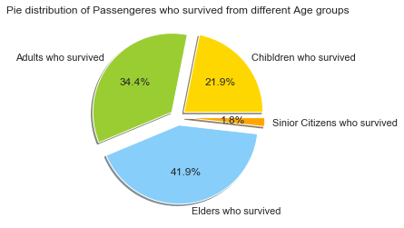

```python
size_age_survived= [len(Children_survived.axes[0]),len(Adults_survived.axes[0]),len(Elders_survived.axes[0]),len(Seniors_survived.axes[0])]
plt.title('Pie distribution of Passengeres who survived from different Age groups')
plt.pie(size_age_survived, labels= ['Chibldren who survived','Adults who survived','Elders who survived','Sinior Citizens who survived'],autopct='%1.1f%%', shadow=True,colors = ['gold', 'yellowgreen', 'lightskyblue','orange'],explode=(0.1,0.1,0.1,0.1))
plt.show()
```

## Age groups of Survivors

```python
class1_survived= x[(class1) & (survived)]
class2_survived = x[(class2) & (survived)]
class3_survived = x[(class3) & (survived)]
```

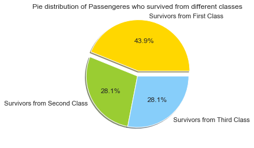

```python
size_class_survived= [len(class1_survived.axes[0]),len(class2_survived.axes[0]),len(class2_survived.axes[0])]
plt.title('Pie distribution of Passengeres who survived from different classes')
plt.pie(size_class_survived, labels= ['Survivors from First Class','Survivors from Second Class','Survivors from Third Class'],autopct='%1.1f%%', shadow=True,colors = ['gold', 'yellowgreen', 'lightskyblue'],explode=(0.1,0,0))
plt.show()
```

```python
def count_elements(seq) -> dict:
     """Tally elements from `seq`."""
     hist = {}
     for i in seq:
         hist[i] = hist.get(i, 0) + 1
     return hist
```

This is a function that counts the frequency of the data in the given column and stores it in form of dictionary

```python
survived_filters=x[survived]
print("No. of passengers who survived = " + str(len(survived_filters.axes[0]) + 1 ))
survived_age= survived_filters['Age']
ar = np.array(survived_age.dropna())
age_fr=count_elements(list(ar))
```

```
No. of passengers who survived = 343
```

#### Here we can store all the data of the survivors in a variable called survived_filters

We have printed the number of passengers whoo survived dropna() function is used to drop the missing values of age in order to get a continuous line in the graph

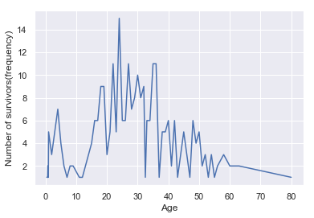

```python
sns.set()
o_age_fr= collections.OrderedDict(sorted(age_fr.items()))
X_axis= list(o_age_fr.keys())
Y_axis= list(o_age_fr.values())
plt.xlabel('Age')
plt.ylabel('Number of survivors(frequency)')
plt.plot(X_axis,Y_axis)
plt.show()
```

## Distribution of Number of Survivors according to ages

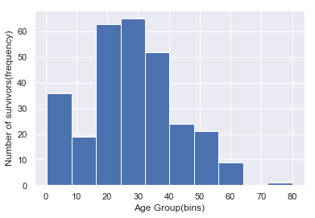

```python
plt.xlabel('Age Group(bins)')
plt.ylabel('Number of survivors(frequency)')
plt.hist(ar)
plt.show()
```

## Histogram of Age of people Vs The number of survivors